# (Ford GoBike)

## by (Omar Alsaghan)

## Investigation Overview

> my goal is to help identifying which type of consumer you should focus on more.

## Dataset Overview

> Ford GoBike is a regional public bicycle sharing system in the San Francisco Bay Area, California. Beginning operation in August 2013 as Bay Area Bike Share, the Ford GoBike system currently has over 2,600 bicycles in 262 stations across San Francisco, East Bay and San Jose. On June 28, 2017, the system officially launched as Ford GoBike in a partnership with Ford Motor Company.

> Ford GoBike, like other bike share systems, consists of a fleet of specially designed, sturdy and durable bikes that are locked into a network of docking stations throughout the city. The bikes can be unlocked from one station and returned to any other station in the system, making them ideal for one-way trips. The bikes are available for use 24 hours/day, 7 days/week, 365 days/year and riders have access to all bikes in the network when they become a member or purchase a pass.

## (Visualization 1)

> the duration spent by the riders

```python
df['duration_in_minute']= df['duration_sec']/60
df['duration_in_hour']= df['duration_in_minute']/60;
```

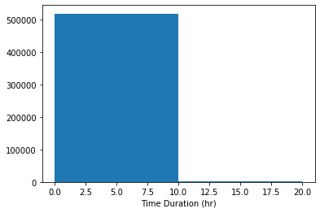

```python
bins = np.arange(0, df['duration_in_hour'].max()+1, 10)
plt.hist(data = df, x = 'duration_in_hour', bins = bins)
plt.xlabel('Time Duration (hr)')
plt.show();
```

## (count of customers vs subscribers)

> number of subscriber who rides is way more than the customers

[figure not shown]

```python
sb.countplot(data=df,x='user_type')
plt.title('Average bike trip by Subscriber and customer')
```

[output not shown]

## (Average trip duration per user type)

#### the customers spend more time compared the subscribers

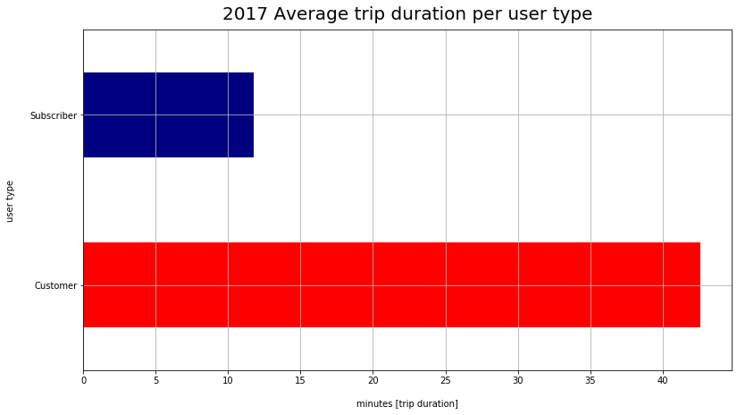

```python
new_color=['red', 'navy']
ax = df.groupby('user_type')['duration_in_minute'].mean().plot(kind='barh', color=new_color, figsize=(13,7))
ax.set_title('2017 Average trip duration per user type', fontsize=20, y=1.015)
ax.set_ylabel('user type', labelpad=16)
ax.set_xlabel('minutes [trip duration]', labelpad=16)
plt.grid();
```

# Summary

## as a conclusion its not useful to focus on one user type and neglect the other because one of them has more number of riders but the other has larger trip duration and both are indicators should be taken in consideration.

```python
jupyter nbconvert slide_deck--to slides --post serve --template output_toggle.tpl
```

[output not shown]